# How Shift Lengths Impact Unifrom Preferences

## Comparing pant preferences against shift duration’s across weeks 1 and 2

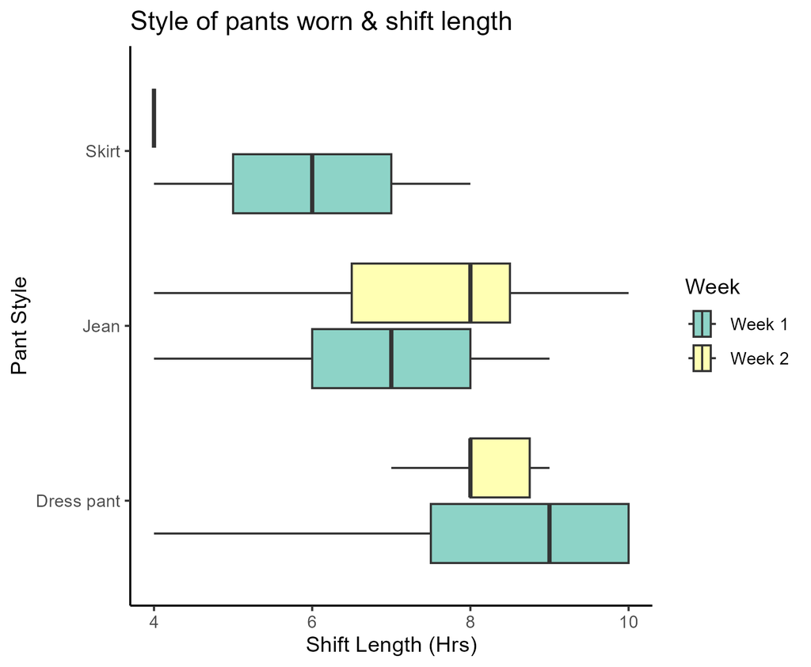

When looking at the boxplot of pant styles against shift length for weeks 1 and 2 we can see that:

- All 3 styles of pant are seen in both weeks of data recording, although there was only one skirt observed in the 2nd week - possibly due to effect of season (summer vs. winter attire);
- Skirts also only observed in medium to short length shift (under 8 hrs, averaging around 6 hrs) - possibly indicating that more causal/part-time worker have a preference towards skirts compared to managers;
- On the other had dress pants, whilst not exclusively, are far more likely to be preferred by individual working shift of longer duration - potentially due to the fact that these are typically managers or full-time staff (also far fewer observed in the 2nd week);
- Jeans are seen across majority of shift length, preference for both shorter and longer shift duration.

## Comparing top preferences against shift duration’s across weeks 1 and 2

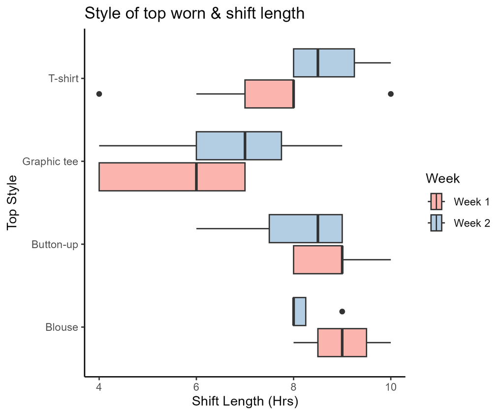

When looking at the box plot of top styles and shift duration across weeks 1 and 2 we can see:

- Blouse seem to be exclusively worn on longer duration shifts - indicating more likely to be worn by managers or full-time employees (more formal attire);
- Graphic tee’s appear to largest spread and have been seen to be worn from shifts as short as 4hrs to as long as 9hrs, in week 1 can see more of a preference towards the medium to shorter length shifts - potentially worm more by casual employees during this time;
- T-shirts are only really worn by one employee, which can be seen in the distribution;
- Button-ups are typically worn for medium to long shifts

## Comparing typical shift lengths across weeks 1 and 2

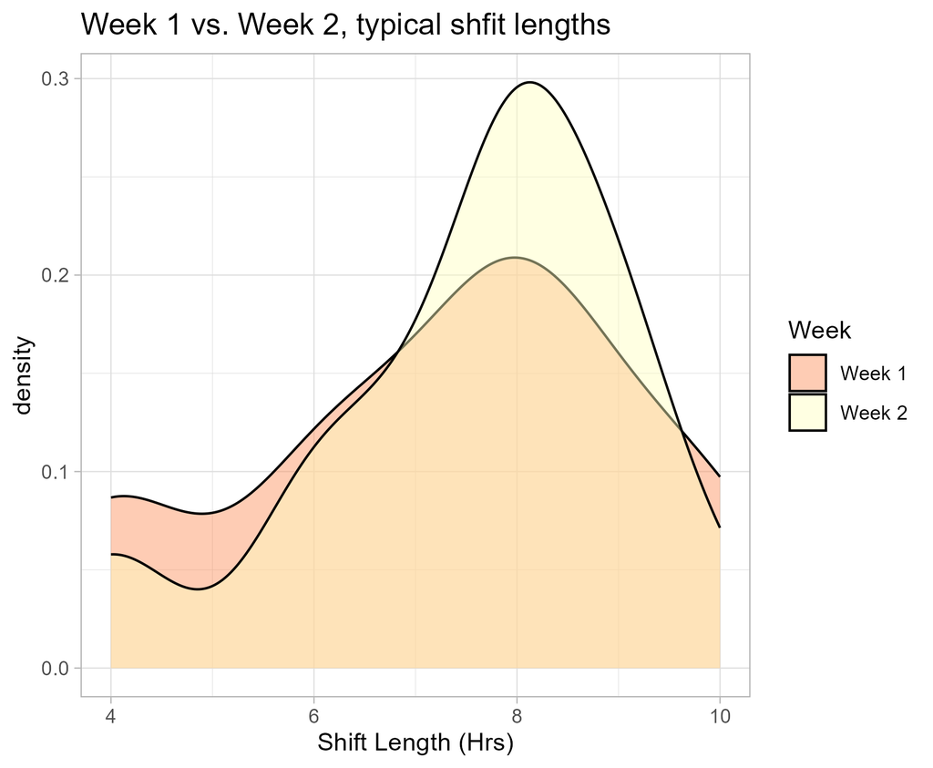

When looking at the density plots of weeks 1 and 2 of when the data was recorded we can see some difference in the standard duration of shift, which could potentially impact the data.

- Can see that this is slightly more shifts of a shorter length (4/5hrs) in week 1 then week 2, and also more shifts of a standard 8 hour day seen in week 2 then week 1 - can most likely be explained by the final few summer worker who stayed on until April leaving, and a slightly more standard rostering resuming